# AstraZeneca Coding Exercise

This is an [R Markdown](http://rmarkdown.rstudio.com) Notebook by Mridul Chaudhary in response to the coding exercise provided by AstraZeneca at https://gist.github.com/azdatascience/6b527b4b9e5563a0202189ef882d5b3d

# Resources

Data source: https://open.fda.gov/apis/drug/label/

Below articles were useful to gain understanding about the drug label data and its API:

- query parameters https://open.fda.gov/apis/query-parameters/
- advanced syntax for API query: https://open.fda.gov/apis/advanced-syntax/
- paging: https://open.fda.gov/apis/paging/
- searchable fields: https://open.fda.gov/apis/drug/event/searchable-fields/

# Required Libraries

```r
#API libraries

library(httr)
library(jsonlite)

#string processing
library(stringr)
library(timeDate)

#data trasformations
library(dplyr)
```

```r
library(tidyr)

#visualization
library(ggplot2)
```

# Part A

## Gather

```r
#Extract all records for manufacturer name "AstraZeneca"

az_api=GET("https://api.fda.gov/drug/label.json?search=openfda.manufacturer_name:astrazeneca&limit=1000")

#Convert raw json data into R objects
data=fromJSON(rawToChar(az_api$content))


data$meta
```

```
## $disclaimer
## [1] "Do not rely on openFDA to make decisions regarding medical care. While we make every effort to ensure that data is accurate, you should assume all results are unvalidated. We may limit or otherwise restrict your access to the API in line with our Terms of Service."
##
## $terms
## [1] "https://open.fda.gov/terms/"
##
## $license
## [1] "https://open.fda.gov/license/"
##
## $last_updated
## [1] "2022-02-21"
##
## $results
## $results$skip
## [1] 0
##
## $results$limit
## [1] 1000
##
## $results$total
## [1] 38
```

## Extract

Above summary shows that there are a total of 38 results from AstraZeneca

```r
#Extract only the desired columns into a dataframe as per problem statement: 'to determine the average number of ingredients (spl_product_data_elements) contained in AstraZeneca medicines per year'

  #extract year from the "effective_time" column
  #chose brand_name instead of generic_name for the drug column
  #elements of the drug from spl_product_data_elements column

data2=data.frame("year"=as.numeric(format(timeDate(data$results$effective_time), "%Y")),
                 "drug"=unlist(data$results$openfda$brand_name),
                 "elements"=unlist(data$results$spl_product_data_elements))


data2[1:2,]
```

|  | year | drug | elements |
| --- | --- | --- | --- |
| 1 | 2022 | SEROQUEL | SEROQUEL quetiapine QUETIAPINE FUMARATE QUETIAPINE POVIDONE, UNSPECIFIED DIBASIC CALCIUM PHOSPHATE DIHYDRATE MICROCRYSTALLINE CELLULOSE SODIUM STARCH GLYCOLATE TYPE A POTATO MAGNESIUM STEARATE HYPROME… |
| 2 | 2020 | Fulvestrant | Fulvestrant Fulvestrant FULVESTRANT FULVESTRANT ALCOHOL BENZYL ALCOHOL BENZYL BENZOATE CASTOR OIL |

```r
data2$elements[1]
```

```
## [1] "SEROQUEL quetiapine QUETIAPINE FUMARATE QUETIAPINE POVIDONE, UNSPECIFIED DIBASIC CALCIUM PHOSPHATE DIHYDRATE MICROCRYSTALLINE CELLULOSE SODIUM STARCH GLYCOLATE TYPE A POTATO MAGNESIUM STEARATE HYPROMELLOSE, UNSPECIFIED POLYETHYLENE GLYCOL, UNSPECIFIED TITANIUM DIOXIDE FERRIC OXIDE RED FERRIC…
```

## Transform

Observation: Upon examining spl_product_data_elements column, there was no obvious deliminator between different elements. The structure varied greatly between drugs and usually contained multiple repeats for drug name itself. A pre-compiled list / database of known pharmaceutical APIs and common additives used in formulations can be helpful here for more accurate results.

Assumption: All unique space separated character strings (other than the drug name) are taken as an estimate for overall number of ingredients.

```r
# add column elements_split: list of all the words separated by space from elements converted to lowercase
data2$elements_split=str_split(str_to_lower(data2$elements),pattern = " ")

# add column elements_split_unique: list of only the unique words from elements_split
data2$elements_split_unique=lapply(data2$elements_split,unique)

#add column num_unique: count unique words from elements
data2$num_unique=unlist(lapply(data2$elements_split_unique,length))

#add column num_drug: count drug_name (can be multiple words) appearing in elements column
data2$num_drug=apply(data2,1,function(x){return(length(grep(x = unlist(x$elements_split_unique),
                                                            pattern = paste(unlist(str_split(x$drug,pattern = " ")),collapse="|"),
                                                            ignore.case = TRUE)))})

#checking if both num_unique & num_drug are numeric
class(data2$num_unique)
```

```
## [1] "integer"
```

```r
class(data2$num_drug)
```

```
## [1] "integer"
```

```r
#add column ingredients: estimated number of ingredients
data2$ingredients=data2$num_unique-data2$num_drug


colnames(data2)
```

```
## [1] "year"                  "drug"                  "elements"
## [4] "elements_split"        "elements_split_unique" "num_unique"
## [7] "num_drug"              "ingredients"
```

```r
#pre-final form of data, subset of required columns
data3=data2[,c("year","drug","ingredients")]

data3[1:5,]
```

|  | year | drug | ingredients |
| --- | --- | --- | --- |
| 1 | 2022 | SEROQUEL | 32 |
| 2 | 2020 | Fulvestrant | 5 |
| 3 | 2019 | Budesonide and Formoterol Fumarate Dihydrate | 7 |
| 4 | 2021 | BYDUREON BCise | 21 |
| 5 | 2022 | Crestor | 26 |

```r
#group the data per year and summarize the drug names and avg num of ingredients
AZ=as.data.frame(data3 %>% group_by(year) %>% summarise(drug_names=toString(drug),avg_number_of_ingredients=mean(ingredients),.groups = "drop") %>% ungroup() )


AZ
```

| year | drug_names | avg_number_of_ingredients |
| --- | --- | --- |
| 2019 | Budesonide and Formoterol Fumarate Dihydrate, PULMICORT RESPULES, SymlinPen, PULMICORT FLEXHALER, ONGLYZA, CALQUENCE, SYMBICORT, KOMBIGLYZE XR | 14.75000 |
| 2020 | Fulvestrant, QTERN, BREZTRI, FASLODEX, BEVESPI AEROSPHERE, CRESTOR, NEXIUM I.V., Daliresp, MOVANTIK | 14.55556 |
| 2021 | BYDUREON BCise, Byetta, BYDUREON, FARXIGA, KOSELUGO, IRESSA, IMFINZI, LOKELMA, Tudorza Pressair, SAPHNELO, FASENRA, NEXIUM, BRILINTA, Esomeprazole magnesium | 20.00000 |
| 2022 | SEROQUEL, Crestor, SEROQUEL XR, TAGRISSO, Lynparza, XIGDUO XR, LUMOXITI | 27.85714 |

## Visualization

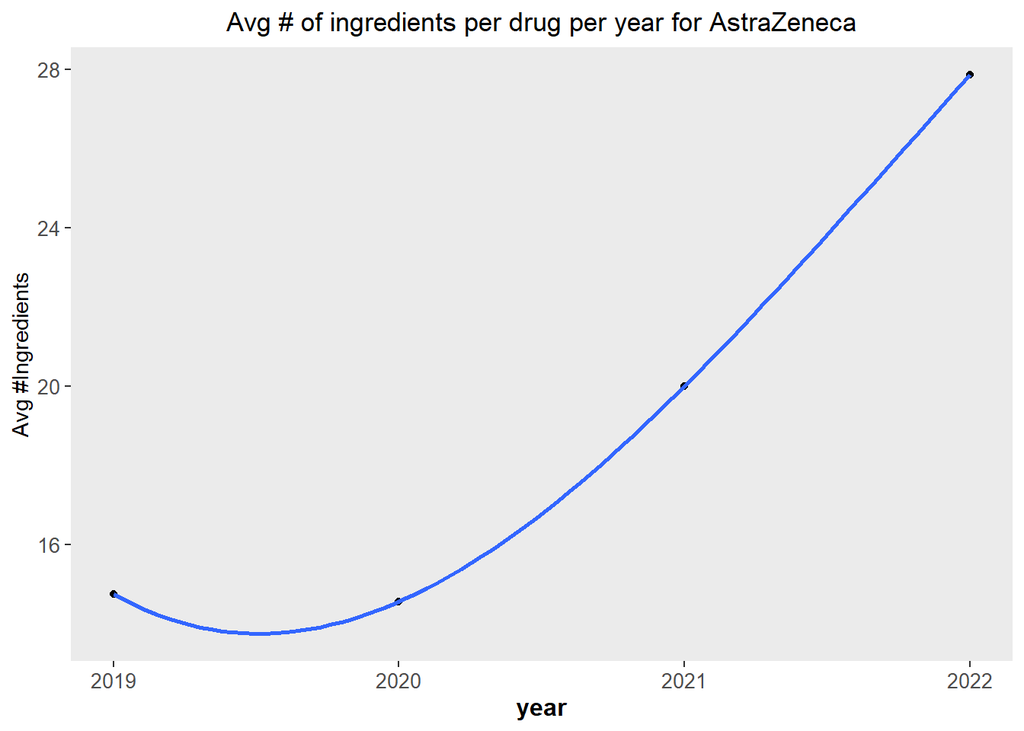

```r
p= ggplot(AZ, aes(x=year,y=avg_number_of_ingredients))+
  geom_point()+
  stat_smooth(method = "lm",formula = y ~ poly(x, 3), se = FALSE)+
  theme(plot.background = element_blank(),
        panel.grid = element_blank(),
        axis.text = element_text(size = 10),
        axis.title.x = element_text(size=12,face="bold"),
        plot.title = element_text(hjust = 0.5))+
  labs(title = "Avg # of ingredients per drug per year for AstraZeneca")+
  ylab("Avg #Ingredients")

p
```

```r
# Reference for following code: https://stackoverflow.com/questions/7549694/add-regression-line-equation-and-r2-on-graph
# GET EQUATION AND R-SQUARED AS STRING
# SOURCE: https://groups.google.com/forum/#!topic/ggplot2/1TgH-kG5XMA

lm_eqn <- function(df){
  m <- lm(y ~ x, df);
  eq <- substitute(italic(y) == a + b %.% italic(x)*","~~italic(r)^2~"="~r2,
                   list(a = round(unname(coef(m)[1]),digits = 4),
                        b = round(unname(coef(m)[2]),digits = 4),
                        r2 = format(summary(m)$r.squared, digits = 4)))
  as.character(as.expression(eq));
}

df=AZ
colnames(df)
```

```
## [1] "year"                      "drug_names"
## [3] "avg_number_of_ingredients"
```

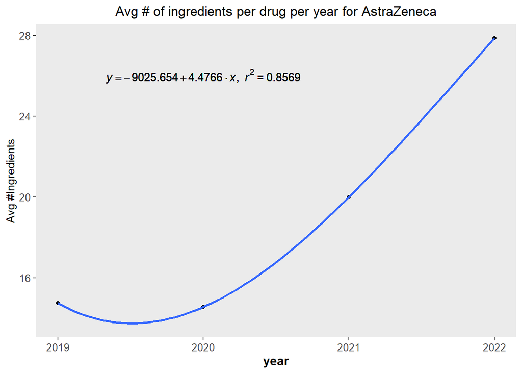

```r
colnames(df)=c("x","drug","y")
eqn_label=lm_eqn(df)

p1 <- p + geom_text(x = 2020, y = 26, label = eqn_label, parse = TRUE)

p1
```

```r
#number of ingredients for 2023 as per linear equation

4.4766*2023 - 9025.654
```

```
## [1] 30.5078
```

# Part B

## Gather

```r
#Test Data

#get all drugs but avoid entries where route or brand name are NULL to get a cleaner (and shorter) data

test_api=GET("https://api.fda.gov/drug/label.json?search=(_exists_:openfda.route)+AND+_exists_:openfda.brand_name&limit=10")

test=fromJSON(rawToChar(test_api$content))

test$meta
```

```
## $disclaimer
## [1] "Do not rely on openFDA to make decisions regarding medical care. While we make every effort to ensure that data is accurate, you should assume all results are unvalidated. We may limit or otherwise restrict your access to the API in line with our Terms of Service."
##
## $terms
## [1] "https://open.fda.gov/terms/"
##
## $license
## [1] "https://open.fda.gov/license/"
##
## $last_updated
## [1] "2022-02-21"
##
## $results
## $results$skip
## [1] 0
##
## $results$limit
## [1] 10
##
## $results$total
## [1] 87129
```

```r
test_api$headers$link
```

```
## [1] "<https://api.fda.gov/drug/label.json?search=%28_exists_%3Aopenfda.route%29%20AND%20_exists_%3Aopenfda.brand_name&limit=10&skip=0&search_after=0%3D00040bfe-001a-484e-bec0-e21e8b27f369>; rel=\"next\""
```

```r
#create a list to store all api responses
api_all_raw=list()

#Get the first 1000 records in 1st call
api_all_raw[[1]]=GET("https://api.fda.gov/drug/label.json?search=(_exists_:openfda.route)+AND+_exists_:openfda.brand_name&limit=1000")

#get remaining records using http link (required little cleaning) from api headers

for (i in 2:88){
api_all_raw[[i]]=GET(str_remove(str_split_fixed(api_all_raw[[i-1]]$headers$link,pattern = ">",2)[,1],pattern = "<"))
}


api_all=list()
for (i in 1:88){
api_all[[i]]=fromJSON(rawToChar(api_all_raw[[i]]$content))
}


api_all_result=list()

for (i in 1:88){
  api_all_result[[i]]=api_all[[i]]$results
}



joined87k=bind_rows(api_all_result, .id = "column_label")

#clear some space
rm(api_all_raw,api_all,api_all_result)
```

## Extract

```r
#Extract only the desired columns into a dataframe as per problem statement: ' calculate the average number of ingredients per year and per delivery route for all manufacturers'

  #extract year from the "effective_time" column
  #chose brand_name instead of generic_name for the drug column
  #route of administration stored in openfda$route
  #elements of the drug from spl_product_data_elements column

j2=data.frame("year"=as.numeric(format(timeDate(joined87k$effective_time), "%Y")),
              "drug"=unlist(lapply(joined87k$openfda$brand_name,function(x){paste(x,collapse = ",")})),
              "route"=unlist(lapply(joined87k$openfda$route,function(x){paste(x,collapse = ",")})),
              "elements"=unlist(lapply(joined87k$spl_product_data_elements,function(x){paste(x,collapse = ",")})))
```

## Transform

```r
# add column elements_split: list of all the words separated by space from elements converted to lowercase
j2$elements_split=str_split(str_to_lower(j2$elements),pattern = " ")

# add column elements_split_unique: list of only the unique words from elements_split
j2$elements_split_unique=lapply(j2$elements_split,unique)

#add column num_unique: count unique words from elements
j2$num_unique=unlist(lapply(j2$elements_split_unique,length))

#cleaning drug names column as some errors came due to presence of brackets
j2$drug=str_remove(j2$drug,pattern = "\\(")
j2$drug=str_remove(j2$drug,pattern = "\\)")

#add column num_drug: count drug_name (can be multiple words) appearing in elements column
j2$num_drug=apply(j2,1,function(x){return(length(grep(x = unlist(x$elements_split_unique),
                                                      pattern = paste(unlist(str_split(x$drug,pattern = " ")),collapse="|"),
                                                      ignore.case = TRUE)))})


#checking if both num_unique & num_drug are numeric
class(j2$num_unique)
```

```
## [1] "integer"
```

```r
class(j2$num_drug)
```

```
## [1] "integer"
```

```r
#add column ingredients: estimated number of ingredients
j2$ingredients=j2$num_unique-j2$num_drug

colnames(j2)
```

```
## [1] "year"                  "drug"                  "route"
## [4] "elements"              "elements_split"        "elements_split_unique"
## [7] "num_unique"            "num_drug"              "ingredients"
```

```r
#pre-final form of data, subset of required columns
j3=j2[,c("year","drug","route","ingredients")]


#group the data per year and summarize the drug names and avg num of ingredients
joined87k_summary=as.data.frame(j3 %>% group_by(year,route) %>% summarise(drug_names=toString(drug),avg_number_of_ingredients=mean(ingredients),.groups = "drop") %>% ungroup() )
```

```r
#There are cases where same drug has multiple route
mix_routes=unique(joined87k_summary$route) |> grep(pattern = ",",value = TRUE)

head(mix_routes)
```

```
## [1] "INTRAMUSCULAR,INTRAVENOUS"
## [2] "INTRAMUSCULAR,INTRATHECAL,INTRAVENOUS,OPHTHALMIC"
## [3] "CUTANEOUS,TOPICAL"
## [4] "DENTAL,ORAL"
## [5] "DENTAL,SUBLINGUAL"
## [6] "INTRAMUSCULAR,INTRAPLEURAL,INTRAVENOUS,SUBCUTANEOUS"
```

```r
#Since the problem statement mentiones to summarize over route, in such a case, each drug is considered multiple times for each of its possible route

unique_routes=unique(unlist(str_split(joined87k_summary$route,pattern = ",")))

#to have separate routes for a same drug as separate records
j4=separate_rows(j3,route,sep = ",")


#final route summary output
route_summary=as.data.frame(j4 %>% group_by(year,route) %>% summarise(drug_names=toString(drug),avg_number_of_ingredients=mean(ingredients),.groups = "drop") %>% ungroup() )


head(route_summary)
```

|  | year | route | drug_names | avg_number_of_ingredients |
| --- | --- | --- | --- | --- |
| 1 | 1993 | TOPICAL | ACT Anticavity Fluoride Kids Bubblegum | 25.00000 |
| 2 | 1994 | TOPICAL | ACT Anticavity Fluoride Mint, ACT Anticavity Fluoride Cinnamon | 30.00000 |
| 3 | 1997 | TOPICAL | Flexall Plus, Flexall Pain Relieving, Flexall Pain Relieving | 25.66667 |
| 4 | 1998 | TOPICAL | Capzasin HP Arthritis Pain Relief, Aspercreme Heat, Arthritis Hot, Gold Bond Ultimate Diabetics | 30.25000 |
| 5 | 1999 | TOPICAL | Sportscreme | 23.00000 |
| 6 | 2002 | TOPICAL | Selsun Blue 2-in-1 | 47.00000 |

## Visualization

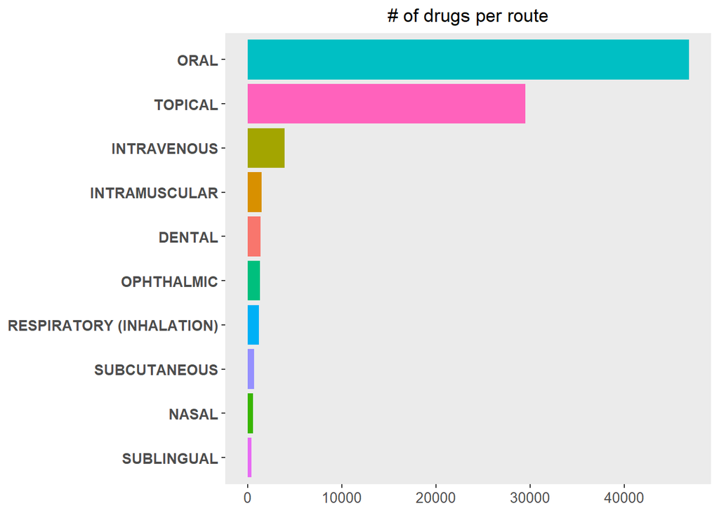

```r
#count the number of drugs for each route
route_count=as.data.frame(table(j4$route))

#order the data frame by decreasing order of the number of drugs
route_count=route_count[order(route_count$Freq,decreasing = TRUE),]

#Visualize #drugs for top 10 most common drug routes
route_barplot=ggplot(route_count[1:10,],aes(x=reorder(Var1,Freq),y=Freq,fill=Var1))+
  geom_bar(stat = "identity",show.legend = FALSE)+
  coord_flip()+
  theme(plot.background = element_blank(),
        panel.grid = element_blank(),
        axis.text = element_text(size = 10),
        axis.text.y = element_text(size=10,face="bold"),
        axis.title = element_blank(),
        plot.title = element_text(hjust = 0.5))+
  labs(title = "# of drugs per route")

route_barplot
```

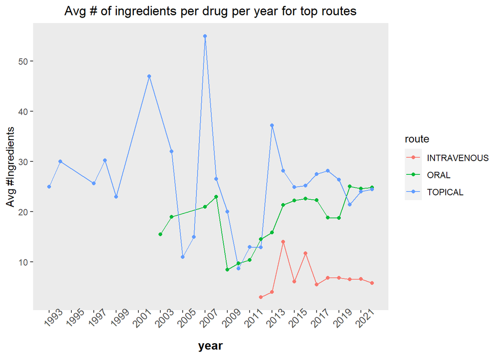

```r
#Visualize avg number of ingredients per year for top 3 routes
route_summary_top3=route_summary[route_summary$route %in% c("ORAL","TOPICAL","INTRAVENOUS"),]


route_per_year=ggplot(route_summary_top3, aes(x=year,y=avg_number_of_ingredients,col=route))+
geom_line()+
  geom_point()+
  scale_x_continuous(breaks = round(seq(min(route_summary_top3$year), max(route_summary_top3$year), by = 2)))+
  theme(plot.background = element_blank(),
        panel.grid = element_blank(),
        axis.text.x = element_text(size = 10,angle = 45),
        axis.title.x = element_text(size=12,face="bold"),
        plot.title = element_text(hjust = 0.5))+
  labs(title = "Avg # of ingredients per drug per year for top routes")+
  ylab("Avg #Ingredients")


route_per_year
```

# Optional

Comments on some optional questions after little exploration:

- How would you code a model to predict the number of ingredients for next year? *Note: Your predictions don’t have to be good !*

  In Part A visualization section, I got a simple linear equation for avg number of ingredients but using R’s lm() function to fit linear models. A prediction of ~30 avg ingredients for 2023 is reasonable given the trend.
- Could you find the most common drug interactions for AstraZeneca medicines?

```r
#extract drug interactions column along with drug name and effective year for AstraZeneca drugs

opt=data$results[,c("effective_time","drug_interactions")]
opt$drug=data$results$openfda$brand_name
unique(unlist(opt$drug))
```

```
##  [1] "SEROQUEL"
##  [2] "Fulvestrant"
##  [3] "Budesonide and Formoterol Fumarate Dihydrate"
##  [4] "BYDUREON BCise"
##  [5] "Crestor"
##  [6] "PULMICORT RESPULES"
##  [7] "QTERN"
##  [8] "SEROQUEL XR"
##  [9] "SymlinPen"
## [10] "Byetta"
## [11] "PULMICORT FLEXHALER"
## [12] "TAGRISSO"
## [13] "BREZTRI"
## [14] "BYDUREON"
## [15] "FARXIGA"
```

[output cut: 23 more lines]

```r
#An example drug interaction record
opt$drug_interactions[1]
```

```
## [[1]]
## [1] "7 DRUG INTERACTIONS â\200¢ Concomitant use of strong CYP3A4 inhibitors: Reduce quetiapine dose to one sixth when coadministered with strong CYP3A4 inhibitors (e.g., ketoconazole, ritonavir) ( 2.5 , 7.1 , 12.3 ) â\200¢ Concomitant use of strong CYP3A4 inducers: Increase quetiapine dose up to …
```

The text shown above may not have a clear structure. So we will need to implement some text mining / NLP solutions. But it entirely depends on how detailed we want our output.

If we want only the number of drugs with which any kind of interaction is reported, we can count the number of occurrences for drug names (apart from the drug for which we are looking for interactions) in the drug interaction text.

But, if we want the nature of interaction with the drug, we may consider extracting meaningful drug - verb pairs and better understand the text using NLP approaches with which I have not had much experience.

- How would you deploy your analysis/model as a tool that other users can use?

  We can build an R shiny dashboard with predefined user input options and visualizations of interest. From searchable fields, we can provide user options to choose from drop downs for key queries of interest (manufacturer, year, etc.). Once user confirms all the inputs, a API query can be designed using user inputs to retrieve corresponding data to build visualizations on.

# Key learnings

The assignment was fun and challenging at the same time. Among many other things, below were key takeaways for me personally

1. Opportunity to explore core pharmaceutical database by FDA
2. Extraordinary variety of drug administration routes
3. Gathering the data using API.